# Introduction to SIDER

Kevin Healy

22 April, 2021

This package estimates Trophic Discrimination Factors (TDFs) based on the imputation function within the **`MCMCglmm`** package (http://cran.r-project.org/web/packages/MCMCglmm/index.html) and includes functionality includes the error associated with building phylogenetic trees using the **`mulTree`** package (https://github.com/TGuillerme/mulTree).

To install **`SIDER`** you will required the `devtools` package. If you dont have `devtools` installed, you will need to run the following:

```r
# Installing devtools
# install.packages("devtools")
```

Following this you can install **`SIDER`** directly from GitHub using the following:

```r
# Installing SIDER
# devtools::install_github("healyke/SIDER@v1.0.0.0")
```

However, if you are reading this vignette as part of the help files you should only need to load the package

```r
library(SIDER)
```

## Read in the data

**`SIDER`** has a data file which contains discrimination factors for a range of species. This data includes what tissue isotopic value were measured from and the basic ecology of the species including its diet (herbivore, etc) and whether it is a marine or terrestrial organism.

We search this data using the `scrumpSider` function.

```r
##search the dataset for a single species
scrumpSider(iso.data = "Larus_delawarensis")
```

|  | species | habitat | taxonomic.class | tissue | diet.type | source.iso.13C | source.iso.15N | delta13C | delta15N | citation |
| --- | --- | --- | --- | --- | --- | --- | --- | --- | --- | --- |
| 177 | Larus_delawarensis | marine | aves | blood | carnivore | -24.3 | 14.2 | -0.3 | 3.1 | Hobson, K. A., & Clark, R. G. (1992). Assessing avian diets using stable isotopes II: factors influencing diet-tissue fractionation.\xcaCondor, 189-197. |
| 178 | Larus_delawarensis | marine | aves | liver | carnivore | -24.3 | 14.2 | -0.4 | 2.7 | Hobson, K. A., & Clark, R. G. (1992). Assessing avian diets using stable isotopes II: factors influencing diet-tissue fractionation.\xcaCondor, 189-197. |
| 179 | Larus_delawarensis | marine | aves | muscle | carnivore | -24.3 | 14.2 | 0.3 | 1.4 | Hobson, K. A., & Clark, R. G. (1992). Assessing avian diets using stable isotopes II: factors influencing diet-tissue fractionation.\xcaCondor, 189-197. |
| 180 | Larus_delawarensis | marine | aves | collagen | carnivore | -24.3 | 14.2 | 2.6 | 3.1 | Hobson, K. A., & Clark, R. G. (1992). Assessing avian diets using stable isotopes II: factors influencing diet-tissue fractionation.\xcaCondor, 189-197. |
| 181 | Larus_delawarensis | marine | aves | feather | carnivore | -24.3 | 14.2 | 0.2 | 3.0 | Hobson, K. A., & Clark, R. G. (1992). Assessing avian diets using stable isotopes II: factors influencing diet-tissue fractionation.\xcaCondor, 189-197. |

```r
NA
```

We can also load the full dataset as an object

```r
##save the entire dataset as an object
isotope_data <- scrumpSider(iso.data = "all")

# View the first rows of the data frame
isotope_data[1,]
```

|  | species | habitat | taxonomic.class | tissue | diet.type | source.iso.13C | source.iso.15N | delta13C | delta15N | citation |
| --- | --- | --- | --- | --- | --- | --- | --- | --- | --- | --- |
| 1 | Rattus_norvegicus | terrestrial | mammalia | liver | herbivore | -25.3 | 4.8 | 3.1 | 1.2 | Kurle, C. M., Koch, P. L., Tershy, B. R., and Croll, D. A. (2014). The effects of sex, tissue type, and dietary components on stable isotope discrimination factors (_13C and _15N) in mammalian omnivor… |

```r
NA
```

```r
##single phylogeny
single_tree <- scrumpSider(tree = 1)
summary(single_tree)
```

```
            Length Class  Mode
edge        60048  -none- numeric
Nnode           1  -none- numeric
tip.label   15013  -none- character
edge.length 30024  -none- numeric
root.edge       1  -none- numeric
```

```r
##all trees
combined_trees <- scrumpSider(tree = "all")
```

In order to estimate a trophic enrichment factor for a new species we need to check that the species is already present in our phylogeny and check what data is available for the new species. `recipeSider` checks for the presence of the following data: **`tissue`** (`blood`, `claws`, `collagen`, `feather`, `hair`, `kidney`, `liver`, `milk`, `muscle`); **`habitat`** (`terrestrial`, `marine`); and **`diet.type`** (`carnivore`, `herbivore`, `omnivore`, `pellet`).

```r
# Checking the data for the species we want to estimate TEF for (Meles meles)
# new_data_test <- recipeSider(species = "Larus_delawarensis",
#                              habitat = "marine",
#                              taxonomic.class = "aves",
#                              tissue = "blood",
#                              diet.type = "carnivore",
#                              tree = combined_trees)

new_data_test <- recipeSider(species = "Larus_argentatus",
                             habitat = "marine",
                             taxonomic.class = "aves",
                             tissue = "blood",
                             diet.type = "carnivore",
                             tree = combined_trees)
```

If the species is not present in the loaded phylogeny (e.g. Komodo dragon - *Varanus komodoensis*), or that some values are missing (e.g. **`tissue`**), we get an error message to indicate what is missing from our data.

> N.B, the following code will throw a stop error if evaluated.

```r
# Some incomplete dataset
new_data_test <- recipeSider(species = "Varanus_komodoensis",
                             habitat = "terrestrial",
                             taxonomic.class = "mammalia",
                             tissue = "NA",
                             diet.type = "omnivore",
                             tree = combined_trees)
```

The `recipeSider` function also formats the data for the new species data so that it can be combined with the data already available within the package using the `prepareSider` function.

We now need to format the data by combining both the isotopic data already available within the package and the data from the new species. We also include what isotope we want to estimate a trophic discrimination value for (either `carbon` or `nitrogen`).

```r
tdf_data_c <- prepareSider(new_data_test,
                          isotope_data,
                          combined_trees,
                          "carbon")
```

> N.B. `isotope_data` is the isotopic dataset already implemented in **`SIDER`**.

We now have a `mulTree` class object, which is required for the imputation analysis. It contains the matched phylogenies, in this case two phylogenies:

```r
tdf_data_c$phy
```

```
2 phylogenetic trees
```

and a dataset containing the TDF and related data with the new species, for which you want to estimate a trophic enrichment factor, at the top with a `NA` for either `delta13C` or `delta15N` depending on isotope.

```r
head(tdf_data_c$data)
```

|  | sp.col | habitat | taxonomic.class | tissue | diet.type | source.iso.13C | delta13C | animal |
| --- | --- | --- | --- | --- | --- | --- | --- | --- |
| 1 | Larus_argentatus | marine | aves | blood | carnivore | NA | NA | Larus_argentatus |
| 25 | Gymnogyps_californianus | terrestrial | aves | blood | carnivore | -21.9 | 0.9 | Gymnogyps_californianus |
| 26 | Gymnogyps_californianus | terrestrial | aves | blood | carnivore | -21.9 | 0.3 | Gymnogyps_californianus |
| 27 | Gymnogyps_californianus | terrestrial | aves | blood | carnivore | -21.9 | 0.3 | Gymnogyps_californianus |
| 28 | Gymnogyps_californianus | terrestrial | aves | blood | carnivore | -21.9 | 0.9 | Gymnogyps_californianus |
| 29 | Gymnogyps_californianus | terrestrial | aves | blood | carnivore | -21.9 | 0.3 | Gymnogyps_californianus |

With the data formatted as a `mulTree` object we can decide on a model which will impute the new species estimate. In this case we will run the full model to estimate delta13C with the fixed factors of diet type and habitat type.

```r
formula.c <- delta13C ~ diet.type + habitat
```

and random terms that includes the `animal` term which is required to include phylogeny into the analysis:

```r
random.terms <- ( ~ animal + species + tissue)
```

As we rely on Bayesian imputation to estimate the missing value we also need to specify a prior, in this case we use a non-informative prior

```r
prior <- list(R = list(V = 1, nu=0.002),
              G = list(G1=list(V = 1, nu=0.002),
                       G2=list(V = 1, nu=0.002),
                       G3=list(V = 1, nu=0.002)))
```

along with the number of iterations to run the chain (`nitt`), the burn-in (`burnin`), the sampling thinning (`thin`), the number of chains to run (`no.chains`) as recommended in the **`MCMCglmm`** guidelines (https://cran.r-project.org/web/packages/MCMCglmm/vignettes/CourseNotes.pdf)}.

```r
nitt <- c(100000)
burnin <- c(10000)
thin <- c(10)
parameters <- c(nitt, thin, burnin)
no.chains <- c(2)
```

> N.B. These settings are only for testing and running a quick example, you can use the following parameters to produce results that pass convergence and avoid autocorrelation

```r
nitt <- c(1200000)
burnin <- c(200000)
thin <- c(500)
parameters <- c(nitt, thin, burnin)
no.chains <- c(2)
```

We need to check that our MCMC chains are converging so we use the Gelman and Rubin diagnostic to check the convergence and also check that the estimated parameters have an effective sample size >1000.

```r
convergence =  c(1.1)
ESS = c(1000)
```

As the function exports the model output, to avoid memory issues within `R` when running over multiple phylogenies, make sure you have set the working directory to somewhere appropriate. Vignettes use a temporary directory, but if you run this code yourself then the files will appear in your working directory (which you may choose to change prior to running this code, and then change back afterwards).

```r
TDF_est.c <- imputeSider(mulTree.data = tdf_data_c,
                         formula = formula.c,
                         random.terms = random.terms,
                         prior = prior,
                         output = "test_c_run",
                         parameters = parameters,
                         chains = no.chains,
                         convergence =  convergence,
                         ESS = ESS)
```

`imputeSider` now runs the selected amount of chains (`no.chains`) for each of the sampled phylogenies and exports the resulting MCMC chains to the working directory. Hence in this case we have run two chains for each of the two sampled trees so there should be four files in your working directory ending with something like `run-tree1_chain2.rda`.

These are the full `MCMCglmm` model outputs for each of the chains run and can be imported back into the `R` for full inspection if required using the `read.mulTree` function. (Note this will require saving your files to a permanent working directory) Notice also that the two other files ending with something similar to `run-tree2_conv`. These give a description of the convergence diagnostics of the chains for each tree. The results of these diagnostics for each tree are also printed in `R` after running `imputeSider` returning whether the Effective sample size exceed ESS for all estimated parameters (with the number for each parameter given as a list), and whether all chains converged for each parameter.

All these models can be separately imported into `R` using `read.mulTree()`. However, since we are only interested in the estimated TDF for our species `imputeSider` only imports the imputed posterior distribution of the estimated TDF for our species.

The contents of the `TDF_est.c$tdf_global` object are the posterior estimate of the imputed TDF aggregated across all chains in the model run (`TDF_est.c$tdf_estimates` is a list containing each posterior chains separately). As a `mcmc` class object, the many functions of the `coda` package provide options for summarising and plotting the distribution.

```r
# Explore the names of the list created by SIDER::imputeSider
names(TDF_est.c)
```

```
[1] "tdf_estimates" "tdf_global"
```

```r
# Calculate summary statistics of the posterior.
# Specifically, the mean and standard deviation would be
# taken from here and used in a mixing model analysis using
# MixSIAR, MixSIR or SIAR for example.
summary(TDF_est.c$tdf_global)
```

```
Iterations = 1:36000
Thinning interval = 1
Number of chains = 1
Sample size per chain = 36000

1. Empirical mean and standard deviation for each variable,
   plus standard error of the mean:

          Mean             SD       Naive SE Time-series SE
      1.059619       1.246317       0.006569       0.007387

2. Quantiles for each variable:

   2.5%     25%     50%     75%   97.5%
-1.3554  0.2306  1.0414  1.8783  3.5619
```

```r
# Credible intervals and the mode of the posterior are obtained
# using the hdrcde package
hdrcde::hdr(TDF_est.c$tdf_global, prob = c(50, 95, 99))
```

```
$hdr
          [,1]     [,2]
99% -2.2177712 4.420639
95% -1.3867904 3.528389
50%  0.1980197 1.846119

$mode
[1] 1.017137

$falpha
        1%         5%        50%
0.01273874 0.04988098 0.25065108
```

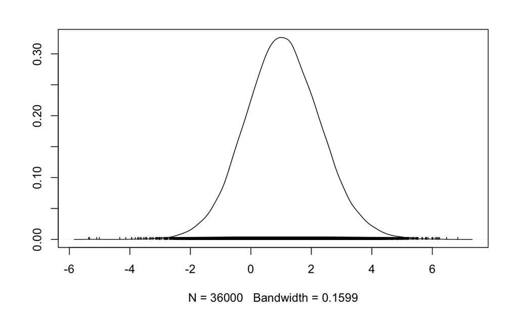

```r
# You can also create density plots of the posterior
coda::densplot(TDF_est.c$tdf_global)
```

[output not shown]